# sLDSC: cell-type specificity deciles

Regina H. Reynolds

UCL

> Aim: use stratified LDSC to test whether PD heritability enriches within top 10% most cell-type specific genes and to check whether there is a linear relationship between heritability enrichment values and cell-type specificity deciles.

# 1 File paths for workflow

```r
source(here::here("R", "file_paths.R"))
source(here::here("R", "EWCE_related_functions.R"))
source(here::here("R", "upsetR_common.R"))
```

# 2 Background

s-LDSC is a method that allows you to determine the relative contribution of an annotation to disease heritability. We use the co-efficient p-value as our read-out for significance, as it tells us whether our annotation is significantly contributing to disease heritability after we have accounted for underlying genetic architecture (as represented by a 53-annotation baseline model, which tags coding regions, enhancer regions, histones, promoters, etc.).

# 3 Running s-LDSC

## 3.1 Creating gene lists

- We will be creating these from specificity matrices generated from our snRNA-seq data.
- Note that a separate specificity matrix was prepared for each disease group i.e. control, PD, PDD and DLB. Thus, we will be generating 320 gene lists (4 disease groups * 8 cell types * 10 deciles).
- We will run each decile through s-LDSC to check whether we have a linear relationship between enrichment and specificity deciles. Ultimately, however, we will only display coefficient p-values for the top 10% of cell-type specific genes.

### 3.1.1 Cell-type clustering

- It is worth knowing how these cell types cluster, thus dendrograms plotted below.

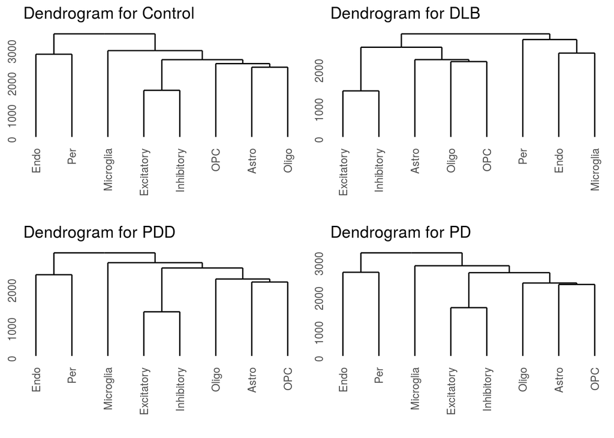

Figure 3.1: Dendrogram showing clustering of cell type specificity quantiles (n = 40) from each cell-type specificity matrix. Distance shown is euclidian distance.

```r
# Load ctd files and plot dendrograms
ctd_files <- list.files(
  file.path(
    path_to_results,
    "snRNA/specificity_matrices/2020_Feb"
    ),
  pattern = "ctd",
  full.names = T)

# Inititate empty vectors
plot_list <- vector(mode = "list", length = length(ctd_files))
ctd_list <- vector(mode = "list", length = length(ctd_files))

# Loop to load data and plot dendrogram
for(i in 1:length(ctd_files)){

  # Load ctd
  ctd_list[[i]] <- readRDS(ctd_files[i])

  # Extract file name
  title <-
    ctd_files[i] %>%
    str_replace(".*/", "") %>%
    str_replace("\\..*", "") %>%
    str_replace(".*_", "")

  # Name list
  names(ctd_list)[i] <- title

  # Create dendrogram
  plot_list[[i]] <-
    plot_dendrogram(ctd_list[[i]] , level = 1) +
    labs(title = str_c("Dendrogram for ", title))


}

ggarrange(plotlist = plot_list)
```

### 3.1.2 Specificity across deciles

- Now let's split these specificity matrices into deciles and check that specificity increases across deciles.
- While doing this, also create a merge of the endothelial and pericyte cell types i.e. vascular cells.

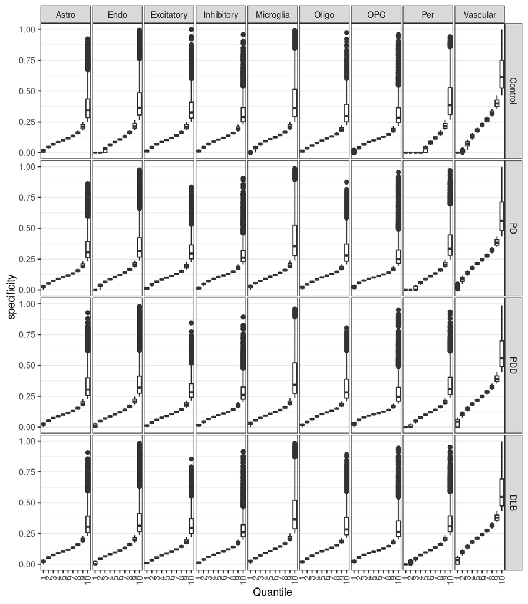

Figure 3.2: Plot of specificity values across quantiles in each cell type in each disease group.

```r
# Create deciles dataframe
decile_df <- ctd_list %>%
  lapply(., function(ctd){

    # Only using level 1 annotations
    ctd[[1]]$specificity %>%
      as.data.frame() %>%
      tibble::rownames_to_column(var = "gene") %>%
      dplyr::mutate(Vascular = Endo + Per) %>%
      tidyr::gather(key = "cell_type", value = "specificity", -gene) %>%
      dplyr::group_by(cell_type) %>%
      dplyr::mutate(quantile = ntile(specificity, 10))
  }) %>%
  qdapTools::list_df2df(col = "Disease_Group")

# Check order of deciles
decile_df %>%
  dplyr::mutate(Disease_Group = fct_relevel(Disease_Group,
                                            c("Control", "PD", "PDD", "DLB"))) %>%
  ggplot(aes(x = as.factor(quantile), y = specificity)) +
  geom_boxplot() +
  facet_grid(Disease_Group ~ cell_type) +
  labs(x = "Quantile") +
  theme_rhr
```

```r
# Check that within each disease group and decile equal number of genes across cell types
decile_df %>%
  dplyr::group_by(quantile, Disease_Group, cell_type) %>%
  dplyr::summarise(n = n()) %>%
  dplyr::arrange(Disease_Group, quantile, cell_type)
```

| quantile | Disease_Group | cell_type | n |
| --- | --- | --- | --- |
| 1 | Control | Astro | 2075 |
| 1 | Control | Endo | 2075 |
| 1 | Control | Excitatory | 2075 |
| 1 | Control | Inhibitory | 2075 |
| 1 | Control | Microglia | 2075 |
| 1 | Control | Oligo | 2075 |
| 1 | Control | OPC | 2075 |
| 1 | Control | Per | 2075 |
| 1 | Control | Vascular | 2075 |
| 2 | Control | Astro | 2075 |

[output cut: 350 more lines]

- As expected, specificity increases across the deciles.

## 3.2 Overlap between top 10% most cell-type specific genes

- When running our lists, it is worth knowing just how much our lists overlap. As we will only report the coefficient p-value for the top 10% in any publication, let's check the overlap here.

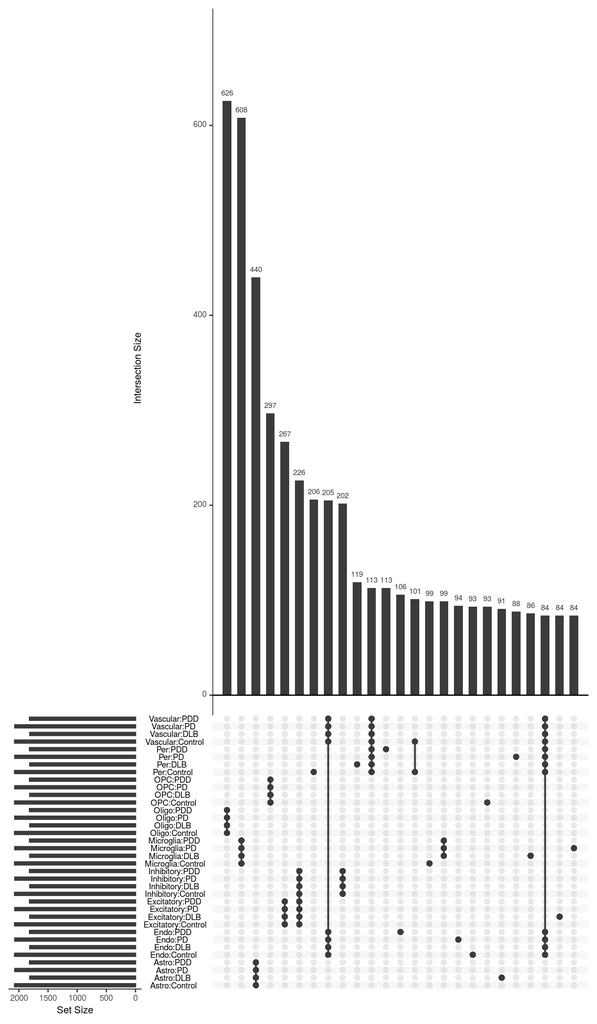

Figure 3.3: **Figure:** Overlap between top 10% cell-type specificity lists from each disease group. In the matrix (lower half of panel), rows represent the top 10% cell-type specificity lists and the columns represent their intersections, with a single black filled circle representing those genes that were not found to be part of an intersection, while black filled circles connected by a vertical line represent genes that intersect across lists. The size of each intersection is shown as a bar chart above the matrix (upper half of panel), while the size of each list is shown to the left of the matrix. Only the top 25 intersections are displayed.

```r
# Create gene list
gene_list <-
  decile_df %>%
  dplyr::filter(quantile == 10) %>%
  dplyr::mutate(cell_type_disease = str_c(cell_type, ":", Disease_Group)) %>%
  group_split(cell_type, Disease_Group)

names(gene_list) <- gene_list %>%
  lapply(., function(df){
    df %>% .[["cell_type_disease"]] %>% unique()
  })

upset(fromList(gene_list %>%
  lapply(., function(df){
    df %>% .[["gene"]]
  })),
  sets = names(gene_list),
  keep.order = TRUE,
  nintersects = 25,
  order.by = "freq")
```

## 3.3 Creating LDSC annotations and running LDSC

- In addition to creating annotations with SNPs found within start and end site for transcription, we also include SNPs found within 100kb upstream and downstream of these sites (as in: https://www.ncbi.nlm.nih.gov/pubmed/29632380)
- As we are looking for critical cell types/tissues via co-efficient p-value, then according to [developer guidelines](https://data.broadinstitute.org/alkesgroup/LDSCORE/readme_baseline_versions) on baseline model we should use baseline LD v1.2 (53 annotations).
- This was run via nohup using the following script: LDSC_cell_type_specificity_deciles.R

```bash
cd /home/rreynolds/projects/Aim2_PDsequencing_wd/LBD-seq-bulk-analyses/

nohup Rscript \
/home/rreynolds/projects/Aim2_PDsequencing_wd/LBD-seq-bulk-analyses/misc_scripts/LDSC_cell_type_specificity_deciles.R \
&>/home/rreynolds/projects/Aim2_PDsequencing_wd/LBD-seq-bulk-analyses/nohup_logs/LDSC_cell_type_specificity_deciles.log&

# LBD GWAS
nohup Rscript \
/home/rreynolds/projects/Aim2_PDsequencing_wd/LBD-seq-bulk-analyses/misc_scripts/LDSC_cell_type_specificity_deciles.R \
&>/home/rreynolds/projects/Aim2_PDsequencing_wd/LBD-seq-bulk-analyses/nohup_logs/LDSC_cell_type_specificity_deciles_LBD.log&
```

- Ran with the following GWASs:

  | Disease | Author_Year | genome_build | N_case | N_ctrl | Notes | date_downloaded_dd_mm_yyyy | download_link | PMID | Link_to_paper |
  | --- | --- | --- | --- | --- | --- | --- | --- | --- | --- |
  | AD | Jansen, 2019 | GRCh37 | 71880 | 383378 |  | 13_12_2019 | https://ctg.cncr.nl/software/summary_statistics | 30617256 | https://pubmed.ncbi.nlm.nih.gov/30617256/ |
  | Lewy body disease | Chia, 2020 | GRCh38 | 2591 | 4027 | Hg38. Pre-dominantely DLB cases (per McKeith criteria), but also contained PDD samples (per Emre criteria). From Sonia Scholz. | 20_05_2020 | Pre-release. |  | https://www.biorxiv.org/content/10.1101/2020.07.06.185066v1 |
  | PD: Age of Onset | Blauwendraat, 2018 | GRCh38 | 17415 |  | Liftover of original (sorted_AAO_april3_18_final_discovery.txt) to GRCh38. | 29_05_2018 | Pre-release, but identical to https://pdgenetics.org/resources | 30957308 | https://www.ncbi.nlm.nih.gov/pubmed/30957308 |
  | PD: Meta5 [ex23andMe] | Nall, 2019 | GRCh38 | 33674 (18618 proxy cases from UK Biobank) | 449056 | Liftover of original file (nallsEtAl2019_excluding23andMe_allVariants.tab.gz) from hg19 to hg38. |  | https://drive.google.com/file/d/1FZ9UL99LAqyWnyNBxxlx6qOUlfAnublN/view | 31701892 | https://www.ncbi.nlm.nih.gov/pubmed/31701892 |
  | PD: Progression, Baseline Cognitive Impairment | Iwaki, 2019 | GRCh38 | 4093 |  | Liftover of original to GRCh38. Study numbers are overall, not for the specific phenotype. For N of specific phenotype refer to column N in summary stats. |  | https://pdgenetics.shinyapps.io/pdprogmetagwasbrowser/ | 31505070 | https://pubmed.ncbi.nlm.nih.gov/31505070/ |
  | PD: Progression, Baseline Depression | Iwaki, 2019 | GRCh38 | 4093 |  | Liftover of original to GRCh38. Study numbers are overall, not for the specific phenotype. For N of specific phenotype refer to column N in summary stats. |  | https://pdgenetics.shinyapps.io/pdprogmetagwasbrowser/ | 31505070 | https://pubmed.ncbi.nlm.nih.gov/31505070/ |
  | PD: Progression, Baseline Dyskinesia | Iwaki, 2019 | GRCh38 | 4093 |  | Liftover of original to GRCh38. Study numbers are overall, not for the specific phenotype. For N of specific phenotype refer to column N in summary stats. |  | https://pdgenetics.shinyapps.io/pdprogmetagwasbrowser/ | 31505070 | https://pubmed.ncbi.nlm.nih.gov/31505070/ |
  | PD: Progression, Baseline Motor Fluctuations | Iwaki, 2019 | GRCh38 | 4093 |  | Liftover of original to GRCh38. Study numbers are overall, not for the specific phenotype. For N of specific phenotype refer to column N in summary stats. |  | https://pdgenetics.shinyapps.io/pdprogmetagwasbrowser/ | 31505070 | https://pubmed.ncbi.nlm.nih.gov/31505070/ |
  | PD: Progression, Survival Cognitive Impairment | Iwaki, 2019 | GRCh38 | 4093 |  | Liftover of original to GRCh38. Study numbers are overall, not for the specific phenotype. For N of specific phenotype refer to column N in summary stats. |  | https://pdgenetics.shinyapps.io/pdprogmetagwasbrowser/ | 31505070 | https://pubmed.ncbi.nlm.nih.gov/31505070/ |
  | PD: Progression, Survival Depression | Iwaki, 2019 | GRCh38 | 4093 |  | Liftover of original to GRCh38. Study numbers are overall, not for the specific phenotype. For N of specific phenotype refer to column N in summary stats. |  | https://pdgenetics.shinyapps.io/pdprogmetagwasbrowser/ | 31505070 | https://pubmed.ncbi.nlm.nih.gov/31505070/ |

  [output cut: 2 more lines]

# 4 Results

- Can multiple correct in a number of ways.
  - Choice of method e.g. Bonferroni (stringent) vs FDR. Will opt for FDR.
  - Number of tests to correct for. In our case, will probably want to correct within a disease group and potentially across GWASs, too.
    - Note: In most recent Skene paper (https://www.biorxiv.org/content/10.1101/528463v3) they correct by number of cell types within a dataset. They **do not** correct for the number of GWASs tested.
- Will apply two forms of multiple test correction:
  1. Stringent: multiple test correct across all cell types and GWASs run within a disease group.
  2. Leniant: filter for well-powered GWASs (i.e. AD, PD and PD AOO) and multiple test correct across all cell types within a disease group (i.e. correcting by the number of cell types).

```r
file_paths <-
  list.files(path =
               file.path(
                 path_to_raw_data,
                 "ldsc_annotations/celltype.deciles/"
               ),
             pattern = ".results",
             recursive = T,
             full.names = T)

results <- LDSCforRyten::Assimilate_H2_results(path_to_results = file_paths) %>%
  LDSCforRyten::Calculate_enrichment_SE_and_logP(., one_sided = "+") %>%
  tidyr::separate(annot_name, into = c("Disease_Group", "cell_type", "decile"),sep = ":") %>%
  dplyr::mutate(Disease_Group = fct_relevel(Disease_Group,
                                            c("Control", "PD", "PDD", "DLB"))) %>%
  dplyr::select(Disease_Group, cell_type, decile, GWAS, everything())

write_delim(results,
            path =
              file.path(
                path_to_results,
                "ldsc/sldsc_celltype_deciles.txt"
                ),
            delim = "\t")
```

## 4.1 Top decile

Let's start by looking at the top decile of specificity.

### 4.1.1 Stringent

This will take into account the number of GWASs and cell types tested.

```r
results <- read_delim(file =
                        file.path(
                          path_to_results,
                          "ldsc/sldsc_celltype_deciles.txt"
                        ),
                      delim = "\t") %>%
  dplyr::mutate(GWAS = str_replace(GWAS, "\\.hg38", ""),
                GWAS = str_replace(GWAS, "2019", ""),
                GWAS = str_replace_all(GWAS, "\\.", "_"))

# Multiple correct co-efficient p-value within disease
results %>%
  dplyr::filter(decile == 10,
                !c(cell_type %in% c("Endo", "Per"))) %>%
  dplyr::group_by(Disease_Group) %>%
  dplyr::mutate(Z_score_FDR = p.adjust(Z_score_P, method = "fdr")) %>%
  dplyr::filter(Enrichment > 0) %>%
  dplyr::select(Disease_Group, cell_type, decile, GWAS, Z_score_FDR, everything(), -contains("SE"), -contains("log")) %>%
  dplyr::arrange(Z_score_FDR)  %>%
  DT::datatable(rownames = FALSE,
                options = list(scrollX = TRUE),
                class = 'white-space: nowrap')
```

| Disease_Group | cell_type | decile | GWAS | Z_score_FDR | Prop._SNPs | Prop._h2 | Prop._h2_std_error | Enrichment | Enrichment_std_error | Enrichment_p | Coefficient | Coefficient_std_error | Coefficient_z-score | Z_score_P |
| --- | --- | --- | --- | --- | --- | --- | --- | --- | --- | --- | --- | --- | --- | --- |
| PDD | Microglia | 10 | AD | 0.208242761099118 | 0.142220727294 | 0.519595157955 | 0.126242627477 | 3.65344185648 | 0.887652804759 | 0.000181306519518 | 3.15639611662e-09 | 1.22401014327e-09 | 2.57873362731 | 0.00495816097855042 |
| PDD | Microglia | 10 | PD_base_dementia | 0.208242761099118 | 0.142220727294 | 0.0110137297107 | 0.0711483138968 | 0.0774411010281 | 0.5002668405 | 0.0195020357532 | 2.17205534028e-07 | 8.13812094565e-08 | 2.66898876877 | 0.00380399971123808 |
| PD | Microglia | 10 | AD | 0.223781728674007 | 0.149518070226 | 0.520816027397 | 0.114323714233 | 3.48329821678 | 0.764614698811 | 5.23359028757e-05 | 2.79132434178e-09 | 1.00173295775e-09 | 2.78649546287 | 0.00266406819850009 |
| Control | Microglia | 10 | AD | 0.450093624816001 | 0.156542834901 | 0.528273325268 | 0.121558714841 | 3.37462475112 | 0.776520464304 | 0.0002120637297 | 2.74177891451e-09 | 1.07444505584e-09 | 2.5518093267 | 0.00535825743828573 |
| Control | Microglia | 10 | PD_base_dementia | 0.49912552047228 | 0.156542834901 | 0.0409402482606 | 0.0776836073753 | 0.261527448934 | 0.496245052828 | 0.0779153837863 | 1.72885620041e-07 | 8.72500813986e-08 | 1.98149522923 | 0.0237678819272514 |
| Control | Astro | 10 | PD_base_motorflux | 0.49912552047228 | 0.158571394523 | 0.452996088056 | 0.187749774474 | 2.85673270023 | 1.184007841 | 0.046495725023 | 2.97056305154e-07 | 1.49225008386e-07 | 1.9906603348 | 0.0232591211230403 |
| DLB | Microglia | 10 | AD | 0.749635510721791 | 0.141637973777 | 0.476463251367 | 0.12888457622 | 3.36395133778 | 0.909957780269 | 0.00180518167306 | 2.46345191885e-09 | 1.3625456781e-09 | 1.80797749275 | 0.0353050018163242 |
| DLB | Excitatory | 10 | PD_meta5_ex23andMe | 0.749635510721791 | 0.186403413808 | 0.304155881987 | 0.0489313122748 | 1.63170768053 | 0.262502232525 | 0.0282270392398 | 1.79274309589e-09 | 9.9433101804e-10 | 1.80296406666 | 0.0356969290819901 |
| DLB | Inhibitory | 10 | PD_surv_dementia | 0.749635510721791 | 0.192231620354 | 0.0942725948173 | 0.0496963099732 | 0.490411487163 | 0.25852307691 | 0.0325361194802 | 1.98007982386e-07 | 1.00570623302e-07 | 1.96884513474 | 0.0244854387581478 |
| DLB | Astro | 10 | AD | 0.778751092207201 | 0.139270705457 | 0.338488353296 | 0.088659100871 | 2.43043468606 | 0.636595474833 | 0.00831076632726 | 9.22034269669e-10 | 8.5831864413e-10 | 1.07423306714 | 0.141359117678149 |

[output cut: 316 more lines]

- With this multiple test correction, no significant enrichment of any GWAS heritability in the top 10% most cell-type specific genes.

### 4.1.2 Lenient

This will take into account the number of cell types tested and uses only well-powered GWASs (AD, PD, PD AOO).

```r
results %>%
  # Filter for top decile, no endo/per cells and only well-powered GWASs
  dplyr::filter(decile == 10,
                !c(cell_type %in% c("Endo", "Per")),
                GWAS %in% c("AD", "PD2018_AOO", "PD_meta5_ex23andMe")) %>%
  dplyr::group_by(Disease_Group, GWAS) %>%
  dplyr::mutate(Z_score_FDR = p.adjust(Z_score_P, method = "fdr")) %>%
  dplyr::filter(Enrichment > 0,
                Z_score_FDR < 0.05) %>%
  dplyr::select(Disease_Group, cell_type, decile, GWAS, Z_score_P, everything(), -contains("SE", ignore.case = F), -contains("log", ignore.case = F)) %>%
  dplyr::arrange(Z_score_P) %>%
  DT::datatable(rownames = FALSE,
                options = list(scrollX = TRUE),
                class = 'white-space: nowrap')
```

| Disease_Group | cell_type | decile | GWAS | Z_score_P | Prop._SNPs | Prop._h2 | Prop._h2_std_error | Enrichment | Enrichment_std_error | Enrichment_p | Coefficient | Coefficient_std_error | Coefficient_z-score | Log_P | Z_score_FDR |
| --- | --- | --- | --- | --- | --- | --- | --- | --- | --- | --- | --- | --- | --- | --- | --- |
| PD | Microglia | 10 | AD | 0.00266406819850009 | 0.149518070226 | 0.520816027397 | 0.114323714233 | 3.48329821678 | 0.764614698811 | 5.23359028757e-05 | 2.79132434178e-09 | 1.00173295775e-09 | 2.78649546287 | 4.2812002791765 | 0.0186484773895006 |
| PDD | Microglia | 10 | AD | 0.00495816097855042 | 0.142220727294 | 0.519595157955 | 0.126242627477 | 3.65344185648 | 0.887652804759 | 0.000181306519518 | 3.15639611662e-09 | 1.22401014327e-09 | 2.57873362731 | 3.74158657902757 | 0.0347071268498529 |
| Control | Microglia | 10 | AD | 0.00535825743828573 | 0.156542834901 | 0.528273325268 | 0.121558714841 | 3.37462475112 | 0.776520464304 | 0.0002120637297 | 2.74177891451e-09 | 1.07444505584e-09 | 2.5518093267 | 3.6735336046477 | 0.0375078020680001 |

- When we correct in this manner, we see:
  - A significant enrichment of AD heritability in microglia from control, PD and PDD.

### 4.1.3 Nominal results (unadjusted p < 0.05)

- No multiple test correction. Only AD/PD/PD AOO used.

```r
results %>%
  # Filter for top decile, no endo/per cells and only well-powered GWASs
  dplyr::filter(decile == 10,
                !c(cell_type %in% c("Endo", "Per")),
                GWAS %in% c("AD", "PD2018_AOO", "PD_meta5_ex23andMe"),
                Enrichment > 0,
                Z_score_P < 0.05) %>%
  dplyr::select(Disease_Group, cell_type, decile, GWAS, Z_score_P, everything(), -contains("SE", ignore.case = F), -contains("log", ignore.case = F)) %>%
  dplyr::arrange(Z_score_P) %>%
  DT::datatable(rownames = FALSE,
                options = list(scrollX = TRUE),
                class = 'white-space: nowrap')
```

| Disease_Group | cell_type | decile | GWAS | Z_score_P | Prop._SNPs | Prop._h2 | Prop._h2_std_error | Enrichment | Enrichment_std_error | Enrichment_p | Coefficient | Coefficient_std_error | Coefficient_z-score | Log_P |
| --- | --- | --- | --- | --- | --- | --- | --- | --- | --- | --- | --- | --- | --- | --- |
| PD | Microglia | 10 | AD | 0.00266406819850009 | 0.149518070226 | 0.520816027397 | 0.114323714233 | 3.48329821678 | 0.764614698811 | 5.23359028757e-05 | 2.79132434178e-09 | 1.00173295775e-09 | 2.78649546287 | 4.2812002791765 |
| PDD | Microglia | 10 | AD | 0.00495816097855042 | 0.142220727294 | 0.519595157955 | 0.126242627477 | 3.65344185648 | 0.887652804759 | 0.000181306519518 | 3.15639611662e-09 | 1.22401014327e-09 | 2.57873362731 | 3.74158657902757 |
| Control | Microglia | 10 | AD | 0.00535825743828573 | 0.156542834901 | 0.528273325268 | 0.121558714841 | 3.37462475112 | 0.776520464304 | 0.0002120637297 | 2.74177891451e-09 | 1.07444505584e-09 | 2.5518093267 | 3.6735336046477 |
| DLB | Microglia | 10 | AD | 0.0353050018163242 | 0.141637973777 | 0.476463251367 | 0.12888457622 | 3.36395133778 | 0.909957780269 | 0.00180518167306 | 2.46345191885e-09 | 1.3625456781e-09 | 1.80797749275 | 2.74347908426408 |
| DLB | Excitatory | 10 | PD_meta5_ex23andMe | 0.0356969290819901 | 0.186403413808 | 0.304155881987 | 0.0489313122748 | 1.63170768053 | 0.262502232525 | 0.0282270392398 | 1.79274309589e-09 | 9.9433101804e-10 | 1.80296406666 | 1.54933467301324 |
| PDD | Excitatory | 10 | PD_meta5_ex23andMe | 0.043673151672803 | 0.198212900404 | 0.295007471384 | 0.0465158687687 | 1.48833638367 | 0.234676293389 | 0.0550903590284 | 1.53206995472e-09 | 8.9617520569e-10 | 1.70956521113 | 1.2589243972846 |

- Nominal enrichment of AD heritability in microglia from DLB.
- Nominal enrichment of PD heritability in excitatory neurons from PDD/DLB.

## 4.2 Linear relationships between deciles

Only those annotations where heritability proportions are above 0 for all deciles are included in this analysis. A negative prop_h2 indicates a model misspecification/GWAS underpowered.

### 4.2.1 Stringent

This will take into account the number of GWASs and cell types tested.

```r
# All deciles should have heritability proportions above 0; a negative prop_h2 indicates a model misspecification/GWAS underpowered
# Keep only those annotations where this is fulfilled across all deciles
filtered <- results %>%
  dplyr::filter(Prop._h2 > 0) %>%
  dplyr::group_by(Disease_Group, cell_type, GWAS) %>%
  dplyr::filter(n() == 10)

# Test of linear regression
lm_results <- filtered %>%
  dplyr::filter(!c(cell_type %in% c("Endo", "Per"))) %>%
  dplyr::group_by(Disease_Group, cell_type, GWAS) %>%
  do(lm(Enrichment ~ as.numeric(decile), data = .) %>%
       broom::tidy())  %>%
  # Multiple correction
  dplyr::group_by(Disease_Group) %>%
  dplyr::mutate(FDR = p.adjust(p.value, method = "fdr"))

# Table of lm where decile is significant term
lm_results %>%
  dplyr::filter(term != "(Intercept)" & FDR < 0.05) %>%
  DT::datatable(rownames = FALSE,
                options = list(scrollX = TRUE),
                class = 'white-space: nowrap')
```

| Disease_Group | cell_type | GWAS | term | estimate | std.error | statistic | p.value | FDR |
| --- | --- | --- | --- | --- | --- | --- | --- | --- |
| Control | Excitatory | AD | as.numeric(decile) | -0.120000308411455 | 0.0347453729293643 | -3.45370615694382 | 0.00864749574175502 | 0.0233281280475252 |
| Control | Oligo | PD_base_dyskinesia | as.numeric(decile) | -0.173841991295351 | 0.0557524255198593 | -3.11810633661899 | 0.0142694789914174 | 0.0359839035435742 |
| Control | Oligo | PD_base_motorflux | as.numeric(decile) | -0.132324726436406 | 0.0460828572456798 | -2.87145230016768 | 0.0207825198760818 | 0.0488761278388776 |
| Control | Oligo | PD_surv_dementia | as.numeric(decile) | -0.0909015068301576 | 0.0212042412217632 | -4.28694928903468 | 0.00266233766890762 | 0.00882374770266526 |
| DLB | Inhibitory | AD | as.numeric(decile) | -0.186988989399061 | 0.050667493975142 | -3.69051189882806 | 0.00612568569425105 | 0.0172775750350671 |
| DLB | Inhibitory | PD2018_AOO | as.numeric(decile) | -0.232173168850903 | 0.0514712295106867 | -4.51073679525565 | 0.00197389139766606 | 0.00700413076591184 |
| DLB | Microglia | AD | as.numeric(decile) | 0.156871497902121 | 0.0508765739853567 | 3.08337385192784 | 0.0150398028449255 | 0.0359647459335176 |
| DLB | Oligo | PD_surv_dementia | as.numeric(decile) | -0.0793891143620363 | 0.0246768099381701 | -3.21715467116506 | 0.0122915663261731 | 0.0307289158154329 |
| DLB | OPC | AD | as.numeric(decile) | -0.172415097480667 | 0.0588482171171893 | -2.92982703515592 | 0.019003178430523 | 0.0418069925471507 |
| DLB | Vascular | AD | as.numeric(decile) | 0.110887117544 | 0.0326358815279299 | 3.39770560354261 | 0.00939228087532331 | 0.024598830863942 |

[output cut: 14 more lines]

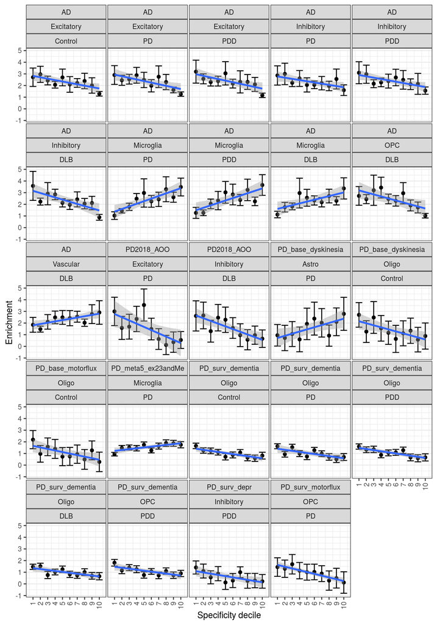

Figure 4.2: GWAS enrichment values in each specificity decile for each cell types. Only significant linear regressions shown; significant threshold set to 5% FDR across cell types and GWAS tested (within each disease group). Error bars indicate 95% confidence intervals. Blue line shows the linear regression slope fitted to the enrichment values. The grey boxing around the blue regression line depict the confidence intervals of the regression line.

```r
# Filtered for term == decile & FDR < 0.05
# Plot significant lm models
lm_results %>%
  dplyr::filter(term != "(Intercept)" & FDR < 0.05) %>%
  dplyr::inner_join(filtered) %>%
  dplyr::ungroup() %>%
  dplyr::mutate(Disease_Group = fct_relevel(Disease_Group,
                                            c("Control", "PD", "PDD", "DLB"))) %>%
  ggplot(aes(x = as.numeric(decile), y = Enrichment)) +
  geom_point() +
  geom_errorbar(aes(ymin = Enrichment.Lower.SE, ymax = Enrichment.Upper.SE)) +
  scale_x_continuous(breaks = seq(0,10,1)) +
  labs(x = "Specificity decile") +
  facet_wrap(vars(GWAS, cell_type, Disease_Group), ncol = 5) +
  geom_smooth(method = "lm") +
  theme_rhr
```

### 4.2.2 Lenient

This will take into account the number of cell types tested and uses only well-powered GWASs (AD, PD, PD AOO).

```r
# Test of linear regression
lm_results <- filtered %>%
  dplyr::filter(!c(cell_type %in% c("Endo", "Per")),
                GWAS %in% c("AD", "PD2018_AOO", "PD_meta5_ex23andMe")) %>%
  dplyr::group_by(Disease_Group, cell_type, GWAS) %>%
  do(lm(Enrichment ~ as.numeric(decile), data = .) %>%
       broom::tidy())  %>%
  # Multiple correction
  dplyr::group_by(Disease_Group, GWAS) %>%
  dplyr::mutate(FDR = p.adjust(p.value, method = "fdr"))

# Table of lm where decile is significant term
lm_results %>%
  dplyr::filter(term != "(Intercept)",
                FDR < 0.05) %>%
  DT::datatable(rownames = FALSE,
                options = list(scrollX = TRUE),
                class = 'white-space: nowrap')
```

| Disease_Group | cell_type | GWAS | term | estimate | std.error | statistic | p.value | FDR |
| --- | --- | --- | --- | --- | --- | --- | --- | --- |
| Control | Excitatory | AD | as.numeric(decile) | -0.120000308411455 | 0.0347453729293643 | -3.45370615694382 | 0.00864749574175502 | 0.0151331175480713 |
| DLB | Inhibitory | AD | as.numeric(decile) | -0.186988989399061 | 0.050667493975142 | -3.69051189882806 | 0.00612568569425105 | 0.0107199499649393 |
| DLB | Inhibitory | PD2018_AOO | as.numeric(decile) | -0.232173168850903 | 0.0514712295106867 | -4.51073679525565 | 0.00197389139766606 | 0.00789556559066425 |
| DLB | Microglia | AD | as.numeric(decile) | 0.156871497902121 | 0.0508765739853567 | 3.08337385192784 | 0.0150398028449255 | 0.0210557239828957 |
| DLB | OPC | AD | as.numeric(decile) | -0.172415097480667 | 0.0588482171171893 | -2.92982703515592 | 0.019003178430523 | 0.0241858634570293 |
| DLB | Vascular | AD | as.numeric(decile) | 0.110887117544 | 0.0326358815279299 | 3.39770560354261 | 0.00939228087532331 | 0.0146102146949474 |
| PD | Excitatory | AD | as.numeric(decile) | -0.137228569671636 | 0.0408018588003808 | -3.36329210742613 | 0.00988340081809075 | 0.0153741790503634 |
| PD | Inhibitory | AD | as.numeric(decile) | -0.103009684979939 | 0.0352956190261111 | -2.9184835915113 | 0.0193361345958486 | 0.027070588434188 |
| PD | Microglia | AD | as.numeric(decile) | 0.223683445090424 | 0.046249697894858 | 4.83643040434418 | 0.00129399391737218 | 0.00258798783474436 |
| PD | Microglia | PD_meta5_ex23andMe | as.numeric(decile) | 0.0726918899046545 | 0.0225704319690494 | 3.22066897099427 | 0.0122269158034695 | 0.0213971026560717 |

[output cut: 4 more lines]

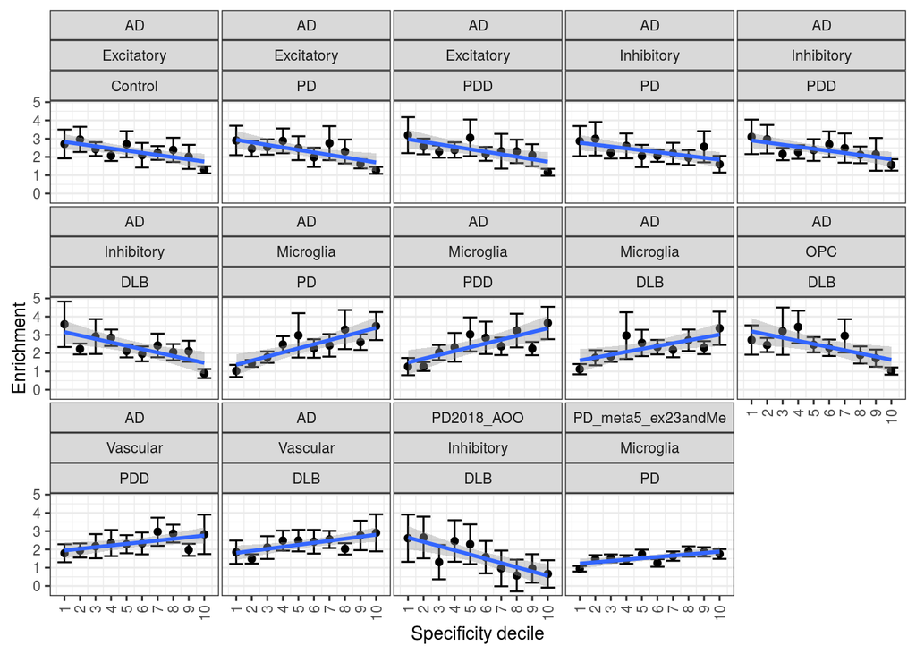

Figure 4.3: GWAS enrichment values in each specificity decile for each cell types. Only significant linear regressions shown; significant threshold set to 5% FDR across cell types (within each disease group). Error bars indicate 95% confidence intervals. Blue line shows the linear regression slope fitted to the enrichment values. The grey boxing around the blue regression line depict the confidence intervals of the regression line.

```r
# Filtered for term == decile & FDR < 0.05
# Plot significant lm models
lm_results %>%
  dplyr::filter(term != "(Intercept)",
                FDR < 0.05) %>%
  dplyr::inner_join(filtered) %>%
  dplyr::ungroup() %>%
  dplyr::mutate(Disease_Group = fct_relevel(Disease_Group,
                                            c("Control", "PD", "PDD", "DLB"))) %>%
  ggplot(aes(x = as.numeric(decile), y = Enrichment)) +
  geom_point() +
  geom_errorbar(aes(ymin = Enrichment.Lower.SE, ymax = Enrichment.Upper.SE)) +
  scale_x_continuous(breaks = seq(0,10,1)) +
  labs(x = "Specificity decile") +
  facet_wrap(vars(GWAS, cell_type, Disease_Group), ncol = 5) +
  geom_smooth(method = "lm") +
  theme_rhr
```

- Using the AD GWAS, this analysis highlights:
  - The same result seen previously i.e. enrichment of AD heritability in microglia from PD, PDD and DLB cases.
  - A positive linear relationship between cell-type deciles from PDD- and DLB-derived vascular cells and AD heritability.
  - A negative linear relationship between cell-type deciles from (i) control-, PD and PDD-derived excitatory neurons; (ii) PD-, PDD- and DLB-derived inhibitory neurons; and (iii) DLB-derived OPCs.
- Using the PD and PD AOO GWAS, this analysis highlights:
  - A positive linear relationship between cell-type deciles from PD-derived microglia and PD heritability.
  - A negative linear relationship between cell-type deciles from DLB-derived inhibitory neurons and PD AOO GWAS.